# Statistics for Bioengineering - Weeks 7–10

## Random Forests

Address decision tree limitations through **ensemble learning**:

- Build many trees on **bootstrap samples** of the data
- Randomly select a subset of **features at each split**
- Average predictions across all trees (reduces variance)

**Advantages:** Reduces overfitting, more stable predictions, handles high-dimensional data, provides variable importance measures

## Random Forests in R

- Code
- Key Parameters

```r
library(randomForest)

# Fit random forest
rf_model <- randomForest(Species ~ ., data = iris,
                         ntree = 500, mtry = 2, importance = TRUE)

# View confusion matrix
print(rf_model)

# Variable importance
importance(rf_model)
varImpPlot(rf_model, main = "Variable Importance")
```

| Parameter | Description | Default |
| --- | --- | --- |
| ntree | Number of trees | 500 |
| mtry | Features sampled per split | √p (classification) |
| nodesize | Minimum terminal node size | 1 (classification) |

## Random Forest: Variable Importance

- Output
- Code
- Interpreting Importance

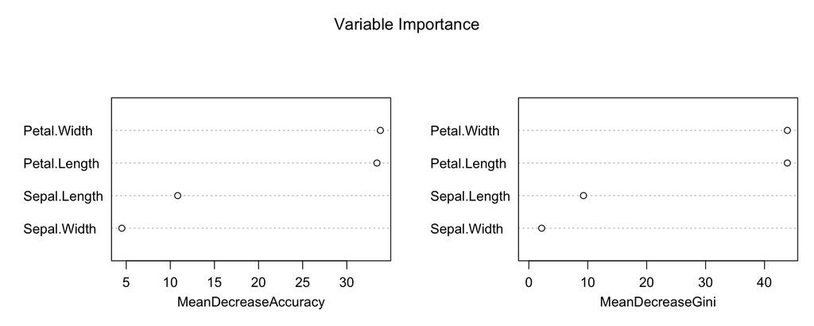

```r
# Variable importance — two measures
varImpPlot(rf_model)

# MeanDecreaseAccuracy: how much accuracy drops when variable is permuted
# MeanDecreaseGini: total decrease in Gini impurity from that variable

# Extract numerical importance
importance(rf_model)

# Partial dependence plots — effect of one variable on prediction
# install.packages("pdp")
library(pdp)
partial(rf_model, pred.var = "Petal.Length", plot = TRUE,
        rug = TRUE, plot.engine = "ggplot2")

partial(rf_model, pred.var = "Petal.Width", plot = TRUE,
        rug = TRUE, plot.engine = "ggplot2")
```

- **Mean Decrease Accuracy**: More reliable; measures prediction degradation when variable is shuffled
- **Mean Decrease Gini**: Biased toward variables with many categories; faster to compute
- **Partial dependence**: Shows the marginal effect of a variable, averaging over all other variables
- Use importance to identify key drivers, not for formal hypothesis testing

## ROC Curves and AUC

**ROC** (Receiver Operating Characteristic) curves summarize classifier performance across all thresholds:

- Plots True Positive Rate vs. False Positive Rate
- **AUC** (Area Under Curve) is a single-number summary
- 0.5 = random guessing, 1.0 = perfect classification

| AUC | Interpretation |
| --- | --- |
| 0.5–0.7 | Poor |
| 0.7–0.8 | Fair |
| 0.8–0.9 | Good |
| > 0.9 | Excellent |

## Brief Introduction to Neural Networks

Neural networks extend the ideas of linear regression and classification into highly flexible models:

- **Layers** of interconnected nodes (neurons) transform inputs
- Each connection has a learned **weight**
- Non-linear **activation functions** (ReLU, sigmoid) allow complex decision boundaries
- Trained by **backpropagation** — iteratively adjusting weights to minimize a loss function

**Note**

Neural networks are powerful but require large datasets, careful tuning, and are often “black boxes” that are difficult to interpret. For most bioengineering applications with moderate sample sizes, methods like random forests, SVM, or regularized regression are more appropriate starting points.

## Simple Neural Network in R

- Code
- Key Points

```r
library(nnet)

# Scale predictors for neural network
iris_scaled <- iris
iris_scaled[, 1:4] <- scale(iris[, 1:4])

# Train/test split
set.seed(42)
train_idx <- sample(nrow(iris_scaled), 0.7 * nrow(iris_scaled))
train <- iris_scaled[train_idx, ]
test  <- iris_scaled[-train_idx, ]

# Fit single hidden layer neural network
nn_model <- nnet(Species ~ ., data = train,
                 size = 5,       # 5 hidden neurons
                 decay = 0.01,   # weight decay (regularization)
                 maxit = 500,
                 trace = FALSE)

# Predictions and accuracy
nn_pred <- predict(nn_model, test, type = "class")
accuracy <- mean(nn_pred == test$Species)
cat("Neural Network Accuracy:", round(accuracy, 3))
table(Predicted = nn_pred, Actual = test$Species)

# Compare with random forest
library(randomForest)
rf_model <- randomForest(Species ~ ., data = train)
rf_pred <- predict(rf_model, test)
cat("\nRandom Forest Accuracy:", round(mean(rf_pred == test$Species), 3))
```

- `nnet` implements a single hidden layer — sufficient for many problems
- `size`: number of hidden neurons (start small, increase if underfitting)
- `decay`: L2 regularization to prevent overfitting
- Always scale inputs before training a neural network
- For deep learning, explore `keras` and `tensorflow` packages
- This is a brief introduction — take a dedicated ML course for depth

## In-Class Exercise: PCA and Ordination

**Exercise**

**Dataset**: Built-in `iris` data

**Tasks**:

1. Perform PCA on the four numeric variables
2. Determine how many components to retain using a scree plot
3. Create a biplot showing samples colored by species
4. Interpret which variables drive the separation
5. Compare PCA results with an LDA — do the same variables dominate?

```r
# Starter code
data(iris)
iris_pca <- prcomp(iris[, 1:4], center = TRUE, scale. = TRUE)
summary(iris_pca)

# Scree plot
var_explained <- iris_pca$sdev^2 / sum(iris_pca$sdev^2)
barplot(var_explained, names.arg = paste0("PC", 1:4),
        ylab = "Proportion of Variance", main = "Scree Plot")

# PCA plot colored by species
plot(iris_pca$x[, 1:2],
     col = as.numeric(iris$Species) + 1, pch = 19,
     xlab = paste0("PC1 (", round(var_explained[1] * 100, 1), "%)"),
     ylab = paste0("PC2 (", round(var_explained[2] * 100, 1), "%)"),
     main = "PCA of Iris Dataset")
legend("topright", levels(iris$Species), col = 2:4, pch = 19)

# Examine loadings
print(iris_pca$rotation)
```

# Course Summary: Choosing the Right Method

## Which Method Should I Use?

**Start by asking these questions:**

1. **What is your goal?** Inference (understanding) vs. Prediction
2. **What type is your response variable?** Continuous, binary, count, time-to-event, multivariate
3. **How many predictors?** Few vs. many; continuous vs. categorical vs. mixed
4. **Sample size?** Small (n < 30), moderate (30–200), large (200+)

## Method Selection: Inference

| Response | Predictors | Method | Week |
| --- | --- | --- | --- |
| Continuous | 1 continuous | Simple regression | 6 |
| Continuous | Multiple continuous | Multiple regression | 7 |
| Continuous | Continuous + categorical | ANCOVA | 7 |
| Continuous | 1 categorical (2 groups) | t-test / ANOVA | 6 |
| Continuous | Multiple categorical | Multifactor ANOVA | 7 |
| Continuous | Categorical (repeated) | Repeated measures / mixed model | 7 |
| Binary | Continuous/mixed | Logistic regression | 8 |
| Count | Continuous/mixed | Poisson / negative binomial regression | 8 |
| Time-to-event | Continuous/mixed | Cox proportional hazards | 8 |
| Multiple continuous | Categorical | MANOVA → DFA | 10 |

## Method Selection: Prediction & Exploration

| Goal | Data Type | Method | Week |
| --- | --- | --- | --- |
| Classify | Labeled, few features | LDA, logistic regression | 8, 10 |
| Classify | Labeled, complex boundaries | KNN, SVM, random forest | 9, 10 |
| Classify | Labeled, many features | Regularized regression, random forest | 8, 10 |
| Reduce dimensions | Continuous | PCA | 10 |
| Reduce dimensions | Distance/dissimilarity | PCoA, NMDS | 10 |
| Visualize clusters | High-dimensional | t-SNE, UMAP | 10 |
| Find groups | No labels | K-means, hierarchical clustering | 9 |
| Test group differences | Distance matrix | PERMANOVA | 10 |

## The Modeling Progression

How methods connect across weeks — each row builds on the previous:

| Flexibility | Method | Key Addition |
| --- | --- | --- |
| Lowest | Simple linear regression | One predictor, straight line |
| ↓ | Multiple regression | Multiple predictors |
| ↓ | Polynomial regression | Non-linear terms |
| ↓ | Natural splines | Piecewise flexibility |
| ↓ | GAMs | Automatic smoothing |
| ↓ | Random forests | Non-parametric, ensemble |
| Highest | Neural networks | Universal function approximation |

**Tip**

Start simple. Only increase complexity when diagnostic plots show the simpler model is inadequate.

## Reporting Effect Sizes

P-values tell you **whether** an effect exists; effect sizes tell you **how large** it is. Always report both.

| Method | Effect Size Measure | R Code |
| --- | --- | --- |
| t-test | Cohen’s d | `effectsize::cohens_d()` |
| ANOVA | η² (eta-squared), ω² | `effectsize::eta_squared()` |
| Regression | R², partial R² | `summary(model)$r.squared` |
| ANCOVA | Partial η² | `effectsize::eta_squared(type = "partial")` |
| Logistic regression | Odds ratio | `exp(coef(model))` |
| Cox PH | Hazard ratio | `exp(coef(model))` |
| MANOVA | Pillai’s trace, η² | `effectsize::eta_squared()` |
| PERMANOVA | R² | `adonis2()` output |

**Important**

“Statistical significance does not imply practical importance.” A tiny effect can be highly significant with a large enough sample. Effect sizes help you assess whether the difference matters in your bioengineering application.

## Reproducibility Checklist

For every analysis in this course and beyond:

1. **Set a seed** (`set.seed()`) for any analysis involving randomness
2. **Report package versions** (`sessionInfo()` or `renv::snapshot()`)
3. **Use relative paths** and organized project directories
4. **Document your analysis** in Quarto/R Markdown (literate programming)
5. **Report effect sizes** alongside p-values
6. **Share your code** — reproducibility requires transparency